# RLohiya Final Project

## Histograms for Ordinal Data

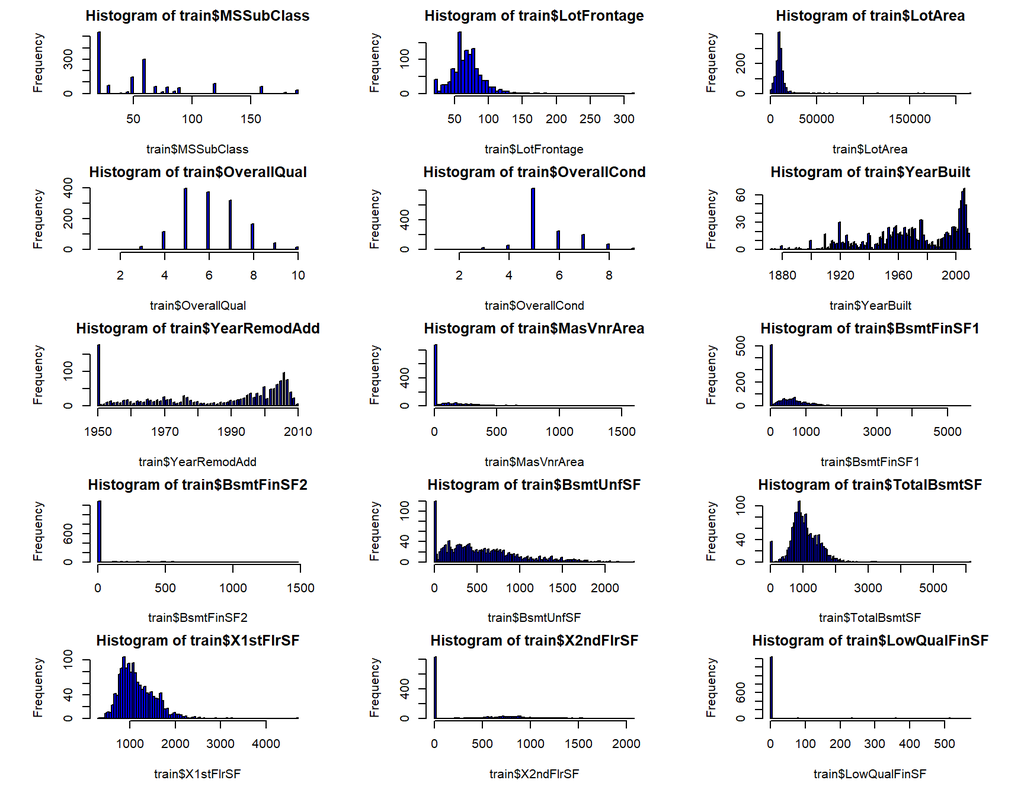

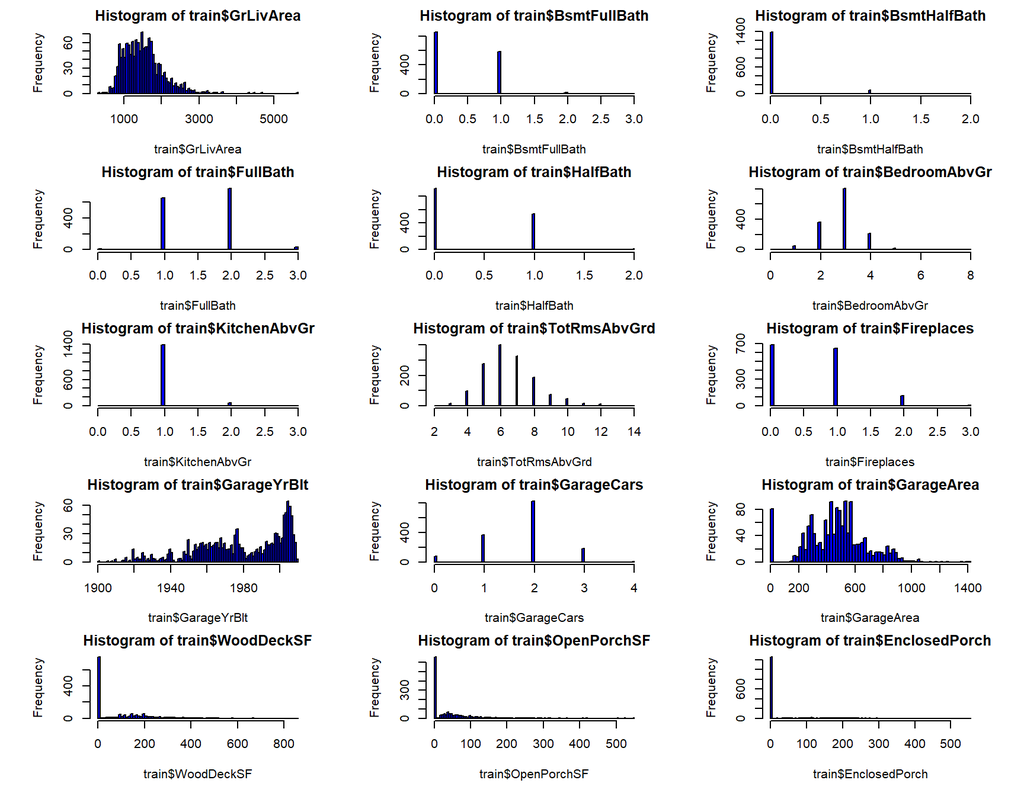

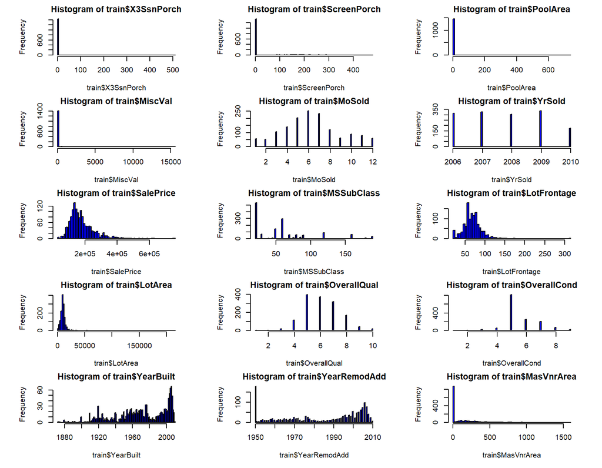

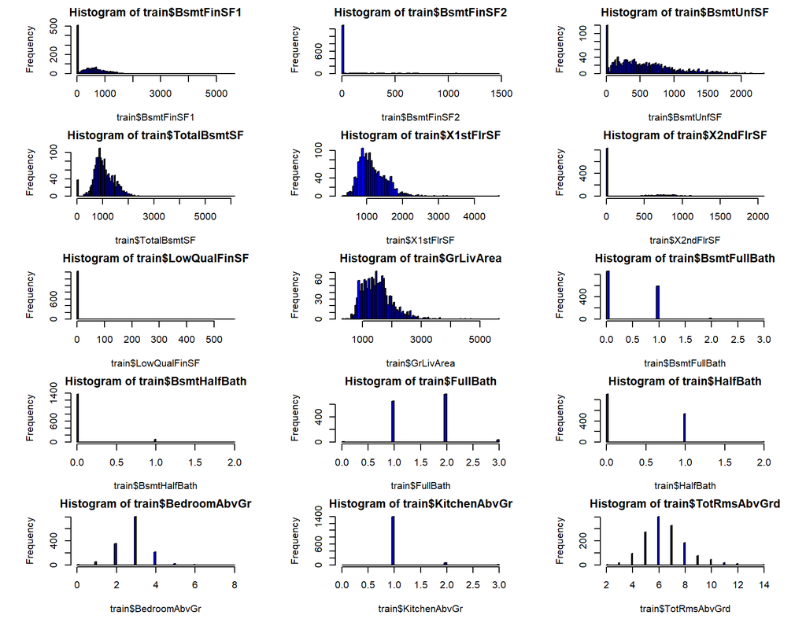

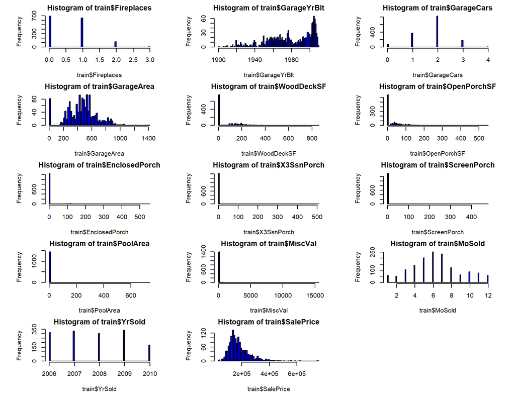

## Derive a correlation matrix for any THREE quantitative variables in the dataset

Selected variables are: SalePrice,TotalBsmtSF,GrLivArea

```r
train_cor <- train[c("SalePrice", "TotalBsmtSF", "GrLivArea")]
train_cor_matrix <- cor(train_cor, use = "complete.obs")
train_cor_matrix
```

```
##             SalePrice TotalBsmtSF GrLivArea
## SalePrice   1.0000000   0.6135806 0.7086245
## TotalBsmtSF 0.6135806   1.0000000 0.4548682
## GrLivArea   0.7086245   0.4548682 1.0000000
```

The Matrix suggests that there are strong to moderate corelation exists between these three variables. ‘Saleprice’ has strong corelations with ‘TotalBsmtSF’ and ‘GrLivArea’ with corelation coefficients of .61 and .708 respectively while ‘TotalBsmtSF’ and ‘GrLivArea’ have moderate corelation between them with coefficient of .45.

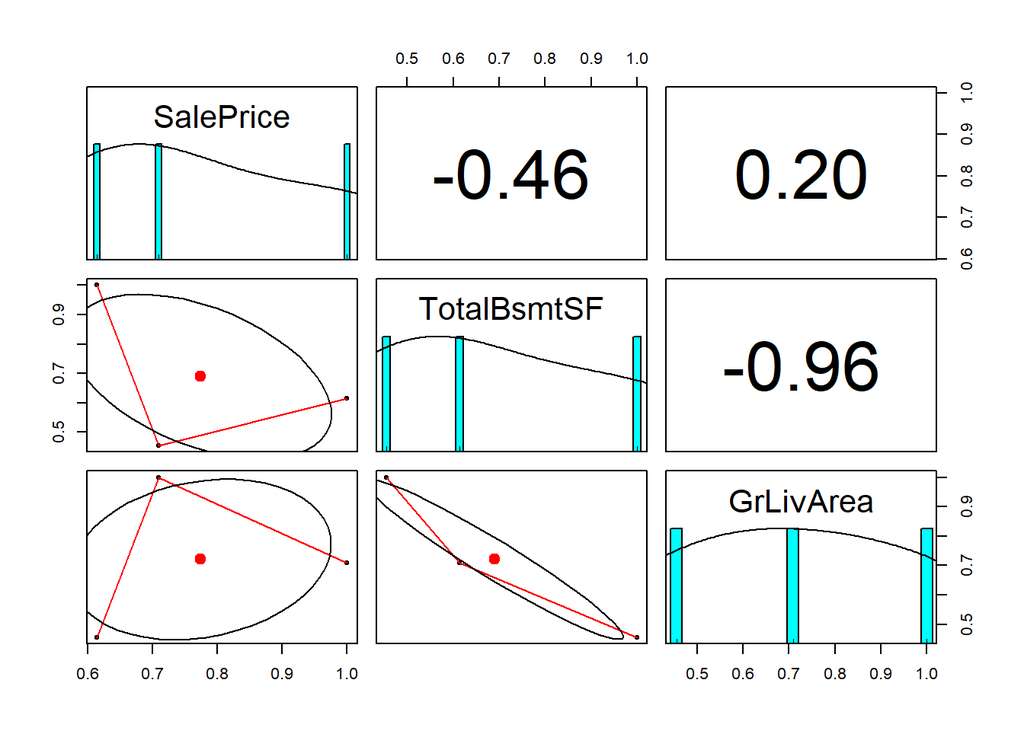

```r
pairs.panels(train_cor_matrix)
```

## Corelation test bwteen each pair:

## Test between ‘TotalBsmtSF’ and ‘SalePrice’

```r
cor.test(train$TotalBsmtSF, train$SalePrice, method = "pearson", conf.level = 0.80)
```

```
##
##  Pearson's product-moment correlation
##
## data:  train$TotalBsmtSF and train$SalePrice
## t = 29.671, df = 1458, p-value < 2.2e-16
## alternative hypothesis: true correlation is not equal to 0
## 80 percent confidence interval:
##  0.5922142 0.6340846
## sample estimates:
##       cor
## 0.6135806
```

## Test between ‘GrLivArea’ and ‘SalePrice’

```r
cor.test(train$GrLivArea, train$SalePrice, method = "pearson", conf.level = 0.80)
```

```
##
##  Pearson's product-moment correlation
##
## data:  train$GrLivArea and train$SalePrice
## t = 38.348, df = 1458, p-value < 2.2e-16
## alternative hypothesis: true correlation is not equal to 0
## 80 percent confidence interval:
##  0.6915087 0.7249450
## sample estimates:
##       cor
## 0.7086245
```

## Test between ‘GrLivArea’ and ‘TotalBsmtSF’

```r
cor.test(train$GrLivArea, train$TotalBsmtSF, method = "pearson", conf.level = 0.80)
```

```
##
##  Pearson's product-moment correlation
##
## data:  train$GrLivArea and train$TotalBsmtSF
## t = 19.503, df = 1458, p-value < 2.2e-16
## alternative hypothesis: true correlation is not equal to 0
## 80 percent confidence interval:
##  0.4278380 0.4810855
## sample estimates:
##       cor
## 0.4548682
```

Since all three p-values are less than .05, the variables are significantly correlated.

## Would you be worried about familywise error? Why or why not?

Yes, there are variables in this dataset that might have impact on the corelation of the the pairs of selected variables that are being tested here. There is a scope for familywise error which might cause rejecting of true Null hypothesis.

# Linear Algebra and Correlation:

Invert your 3 x 3 correlation matrix from above. (This is known as the precision matrix and contains variance inflation factors on the diagonal.) Multiply the correlation matrix by the precision matrix, and then multiply the precision matrix by the correlation matrix. Conduct LU decomposition on the matrix.

## Correlation Matrix:

```r
train_cor_matrix
```

```
##             SalePrice TotalBsmtSF GrLivArea
## SalePrice   1.0000000   0.6135806 0.7086245
## TotalBsmtSF 0.6135806   1.0000000 0.4548682
## GrLivArea   0.7086245   0.4548682 1.0000000
```

## Precision matrix:

```r
pre_matrix <- solve(train_cor_matrix)
pre_matrix
```

```
##              SalePrice TotalBsmtSF   GrLivArea
## SalePrice    2.5582310 -0.93946422 -1.38549273
## TotalBsmtSF -0.9394642  1.60588442 -0.06473842
## GrLivArea   -1.3854927 -0.06473842  2.01124151
```

## Multiplication of correlation matrix by the precision matrix:

```r
round((train_cor_matrix %*% pre_matrix), 2)
```

```
##             SalePrice TotalBsmtSF GrLivArea
## SalePrice           1           0         0
## TotalBsmtSF         0           1         0
## GrLivArea           0           0         1
```

## Multiplication of precision matrix by the correlation matrix:

```r
round((pre_matrix %*% train_cor_matrix), 2)
```

```
##             SalePrice TotalBsmtSF GrLivArea
## SalePrice           1           0         0
## TotalBsmtSF         0           1         0
## GrLivArea           0           0         1
```

Both the matrix is identical.

## LU decomposition of corelation matrix:

```r
cor_lu <- lu(train_cor_matrix)
cor_lu_exd <- expand(cor_lu)

L_cor <- cor_lu_exd$L
U_cor <- cor_lu_exd$U

L_cor
```

```
## 3 x 3 Matrix of class "dtrMatrix" (unitriangular)
##      [,1]       [,2]       [,3]
## [1,] 1.00000000          .          .
## [2,] 0.61358055 1.00000000          .
## [3,] 0.70862448 0.03218829 1.00000000
```

```r
U_cor
```

```
## 3 x 3 Matrix of class "dtrMatrix"
##      [,1]      [,2]      [,3]
## [1,] 1.0000000 0.6135806 0.7086245
## [2,]         . 0.6235189 0.0200700
## [3,]         .         . 0.4972053
```

## LU decomposition of precision matrix:

```r
pre_lu <- lu(pre_matrix)
pre_lu_exd <- expand(pre_lu)

L_pre <- pre_lu_exd$L
U_pre <- pre_lu_exd$U

L_pre
```

```
## 3 x 3 Matrix of class "dtrMatrix" (unitriangular)
##      [,1]       [,2]       [,3]
## [1,]  1.0000000          .          .
## [2,] -0.3672320  1.0000000          .
## [3,] -0.5415823 -0.4548682  1.0000000
```

```r
U_pre
```

```
## 3 x 3 Matrix of class "dtrMatrix"
##      [,1]       [,2]       [,3]
## [1,]  2.5582310 -0.9394642 -1.3854927
## [2,]          .  1.2608831 -0.5735356
## [3,]          .          .  1.0000000
```

Lets multiply the lower and uper matrix and see if it returns the original matrices or not.

```r
L_cor %*% U_cor
```

```
## 3 x 3 Matrix of class "dgeMatrix"
##           [,1]      [,2]      [,3]
## [1,] 1.0000000 0.6135806 0.7086245
## [2,] 0.6135806 1.0000000 0.4548682
## [3,] 0.7086245 0.4548682 1.0000000
```

```r
L_pre %*% U_pre
```

```
## 3 x 3 Matrix of class "dgeMatrix"
##            [,1]        [,2]        [,3]
## [1,]  2.5582310 -0.93946422 -1.38549273
## [2,] -0.9394642  1.60588442 -0.06473842
## [3,] -1.3854927 -0.06473842  2.01124151
```

It returns the original matrices.

# Calculus-Based Probability & Statistics

```r
min(train$GrLivArea)
```

```
## [1] 334
```

The minimum value is 334, so i dont think we need shifting.

Fitting the exponential probability density function:

```r
expo <- fitdistr(train$GrLivArea, densfun = "exponential")
options(scipen = 999)
expo$estimate
```

```
##        rate
## 0.000659864
```

```r
smpl <- rexp(1000, expo$estimate)
```

## Histogram of the samples and the original :

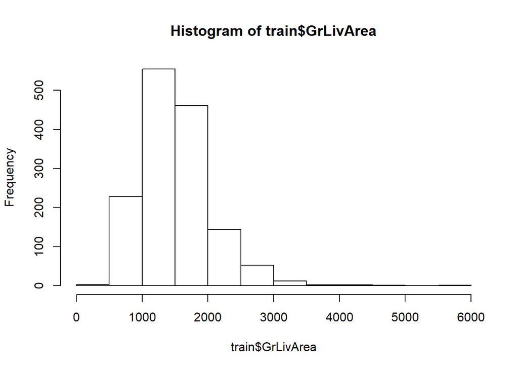

```r
hist(train$GrLivArea)
```

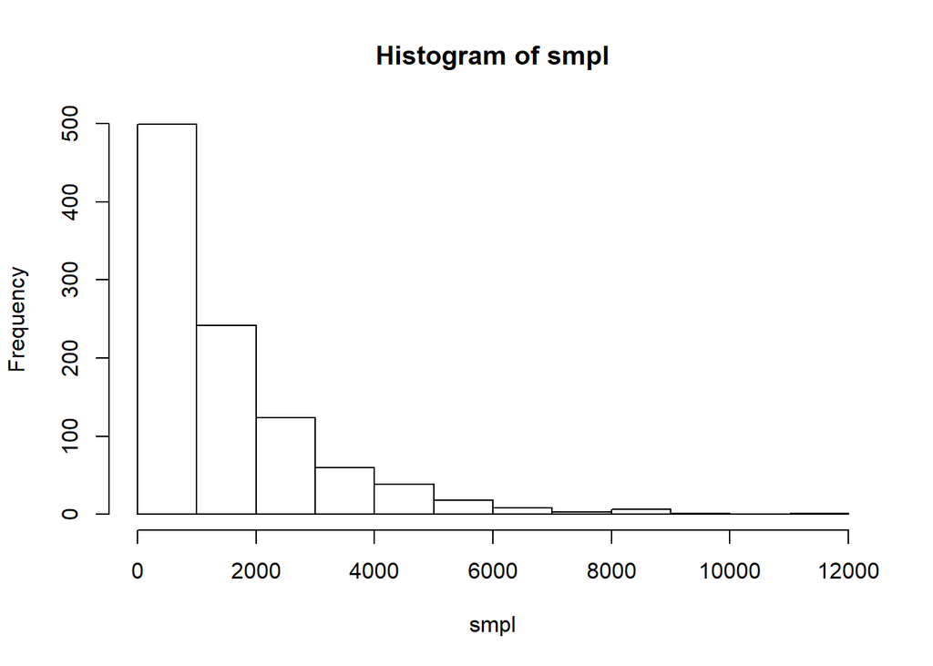

```r
hist(smpl)
```

The samples data is more skewed than the original data.

Using the exponential pdf, find the 5th and 95th percentiles using the cumulative distribution function (CDF):

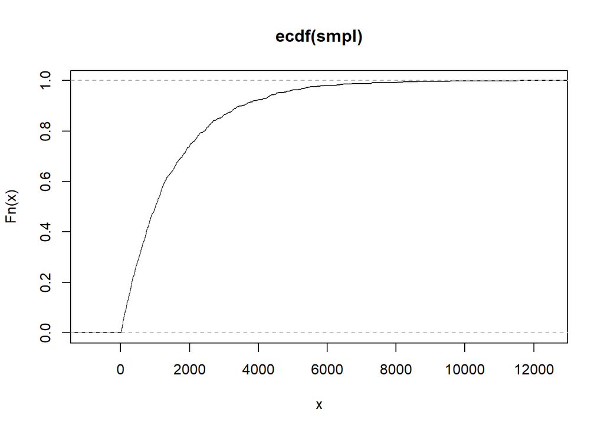

```r
P = ecdf(smpl)
plot(P)
```

```r
c <- quantile(P, c(0.05, 0.95))
c
```

```
##         5%        95%
##   69.04413 4516.50970
```

Generate a 95% confidence interval from the empirical data, assuming normality:

```r
er <- qnorm(0.975) * sd(train$GrLivArea)/sqrt(length(train$GrLivArea))
conf_95 <- c(mean(train$GrLivArea) - er, mean(train$GrLivArea) + er)
conf_95
```

```
## [1] 1488.509 1542.418
```

The 95% confidence interval is 1488.509 1542.418

Provide the empirical 5th percentile and 95th percentile of the data:

```r
e <- quantile(X, c(0.05, 0.95))
e
```

[output not shown]

# Modeling:

## Data preparation

```r
#download the train data
test <- read.csv("https://raw.githubusercontent.com/Riteshlohiya/Data605_Final_Project/master/test.csv", header = TRUE, stringsAsFactors = FALSE)

train <- cbind.data.frame(train, RecType = "Train")
test <- cbind.data.frame(test, RecType = "Test")

train_test <- rbind.data.frame(train, test, stringsAsFactors = FALSE)
```

We will see the missing values in the dataset. For this i have used Amelia package

## Missing value plot before treatment:

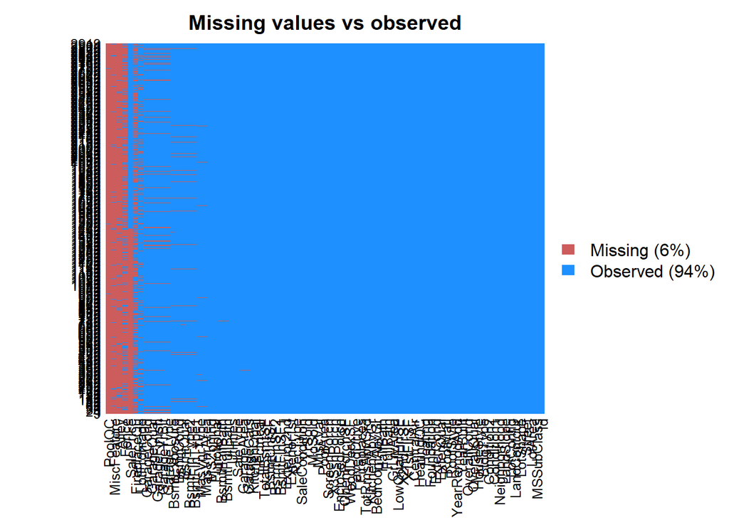

```r
missmap(train_test, main = "Missing values vs observed",  color='dodgerblue')
```

We can see there are lots of missing values. We will replace the missing values.

```r
#Missing value handling

train_test[sapply(train_test, is.factor)] <- lapply(train_test[sapply(train_test, is.factor)], as.character)

train_test$GarageYrBlt[is.na(train_test$GarageYrBlt)] <- train_test$YearBuilt[is.na(train_test$GarageYrBlt)]
train_test$LotFrontage[is.na(train_test$LotFrontage)] <- 0
train_test$MasVnrArea[is.na(train_test$MasVnrArea)] <- 0
train_test$Alley[is.na(train_test$Alley)] <- 'None'
train_test$Utilities[is.na(train_test$Utilities)] <- 'NoSeWa'
train_test$MasVnrType[is.na(train_test$MasVnrType)] <- 'None'
train_test$BsmtQual[is.na(train_test$BsmtQual)] <- 'None'
train_test$BsmtCond[is.na(train_test$BsmtCond)] <- 'Xa'
train_test$BsmtExposure[is.na(train_test$BsmtExposure)] <- 'Xb'
train_test$BsmtFinType1[is.na(train_test$BsmtFinType1)] <- 'Xc'
train_test$BsmtFinType2[is.na(train_test$BsmtFinType2)] <- 'Xd'
train_test$GarageType [is.na(train_test$GarageType )] <- 'Xe'
train_test$GarageFinish[is.na(train_test$GarageFinish)] <- 'Xf'
train_test$GarageQual[is.na(train_test$GarageQual)] <- 'Xg'
train_test$GarageCond[is.na(train_test$GarageCond)] <- 'Xh'
train_test$Electrical[is.na(train_test$Electrical)] <- 'None'
train_test$FireplaceQu[is.na(train_test$FireplaceQu)] <- 'None'
train_test$PoolQC[is.na(train_test$PoolQC)] <- 'None'
train_test$Fence[is.na(train_test$Fence)] <- 'None'
train_test$MiscFeature[is.na(train_test$MiscFeature)] <- 'None'
train_test$MSZoning[is.na(train_test$MSZoning)] <- 'C (all)'
train_test$Utilities[is.na(train_test$Utilities)] <- 'AllPub'
train_test$BsmtFullBath[is.na(train_test$BsmtFullBath)] <- 0
train_test$BsmtHalfBath[is.na(train_test$BsmtHalfBath)] <- 0
train_test$Exterior1st[is.na(train_test$Exterior1st)] <- 'BrkFace'
train_test$Exterior2nd[is.na(train_test$Exterior2nd)] <- 'BrkFace'
train_test$Functional[is.na(train_test$Functional)] <- 'Typ'
train_test$BsmtFinSF1[is.na(train_test$BsmtFinSF1)] <- 0
train_test$BsmtFinSF2[is.na(train_test$BsmtFinSF2)] <- 0
train_test$BsmtUnfSF[is.na(train_test$BsmtUnfSF)] <- 0
train_test$TotalBsmtSF[is.na(train_test$TotalBsmtSF)] <- 0
train_test$GarageCars[is.na(train_test$GarageCars)] <- 0
train_test$GarageArea[is.na(train_test$GarageArea)] <- 0
train_test$SaleType[is.na(train_test$SaleType)] <- 'None'
train_test$SalePrice[is.na(train$SalePrice)] <- 0


train_test[sapply(train_test, is.character)] <- lapply(train_test[sapply(train_test, is.character)], as.factor)
```

## Missing value plot after treatment:

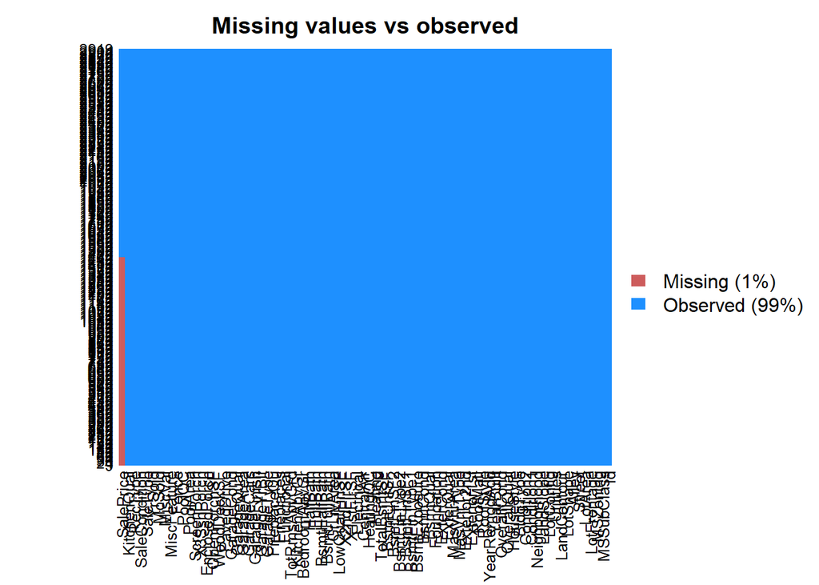

```r
missmap(train_test, main = "Missing values vs observed",  color='dodgerblue')
```

Creating dummy values:

```r
train_test <- createDummyFeatures(train_test, method = "reference")
```

Outlier treatment using mean:

```r
train_test$TotalBsmtSF[train_test$TotalBsmtSF > 6000] <- mean(train_test$TotalBsmtSF[train_test$TotalBsmtSF < 6000])
train_test$X1stFlrSF[train_test$X1stFlrSF > 4000] <- mean(train_test$X1stFlrSF[train_test$X1stFlrSF < 4000])
```

```r
# Split the combined transformed dataset into train and test.
data_train <- train_test[train_test$Train == 1, ]
data_test <- train_test[train_test$Train == 0, ]

# remove id and train/test flag variables from train dataset
data_train <- subset(data_train, select = -c(Id,Train))

# remove SalePrice variables from test dataset
data_test <- subset(data_test, select = -c(SalePrice,Train))
```

## Model 1: Taking all the variables:

```r
model1 <- lm(SalePrice ~ ., data = data_train)
summary(model1)
```

```
##
## Call:
## lm(formula = SalePrice ~ ., data = data_train)
##
## Residuals:
##     Min      1Q  Median      3Q     Max
## -176856   -9170       0    9595  176856
##
## Coefficients: (9 not defined because of singularities)
##                           Estimate   Std. Error t value
## (Intercept)             50689.0010 1058003.9350   0.048
## MSSubClass                -55.2068      82.5886  -0.668
## LotFrontage                 6.4440      22.9780   0.280
## LotArea                     0.7171       0.1084   6.615
## OverallQual              6793.1233    1012.8117   6.707
## OverallCond              5746.9516     870.2750   6.604
## YearBuilt                 332.7269      80.2992   4.144
## YearRemodAdd              105.2342      55.4179   1.899
## MasVnrArea                 20.7177       5.7846   3.582
## BsmtFinSF1                -53.8230      10.1663  -5.294
## BsmtFinSF2                -60.4971      12.7641  -4.740
## BsmtUnfSF                 -71.2768      10.6182  -6.713
## TotalBsmtSF                91.9050      11.1332   8.255
## X1stFlrSF                  44.7238       5.6343   7.938
## X2ndFlrSF                  62.0943       5.6794  10.933
## LowQualFinSF               -3.9424      19.0313  -0.207
## GrLivArea                       NA           NA      NA
## BsmtFullBath             1530.8180    1976.4359   0.775
## BsmtHalfBath             -483.5565    3021.9614  -0.160
## FullBath                 3653.7232    2194.5297   1.665
## HalfBath                 1820.5860    2093.5514   0.870
## BedroomAbvGr            -3613.9719    1361.0583  -2.655
## KitchenAbvGr           -13758.1760    5675.1922  -2.424
## TotRmsAbvGrd             1820.0935     954.6153   1.907
## Fireplaces               6136.5930    2558.0173   2.399
## GarageYrBlt               -43.2256      59.1637  -0.731
## GarageCars               3998.7968    2276.2568   1.757
## GarageArea                 19.1837       7.8565   2.442
## WoodDeckSF                 15.1037       5.8619   2.577
## OpenPorchSF                 0.4612      11.5602   0.040
```

[output cut: 486 more lines]

```
## SaleType.New                      0.157381
## SaleType.None                           NA
## SaleType.Oth                      0.574159
## SaleType.WD                       0.933909
## SaleCondition.AdjLand             0.521393
## SaleCondition.Alloca              0.935951
## SaleCondition.Family              0.891920
## SaleCondition.Normal              0.020496 *
## SaleCondition.Partial             0.960724
## ---
## Signif. codes:  0 '***' 0.001 '**' 0.01 '*' 0.05 '.' 0.1 ' ' 1
##
## Residual standard error: 22570 on 1207 degrees of freedom
## Multiple R-squared:  0.9332, Adjusted R-squared:  0.9193
## F-statistic: 66.94 on 252 and 1207 DF,  p-value: < 0.00000000000000022
```

R-squared is 0.93, This means 93% variance of the sale price can be explained by predictor variables in the model. F-statistic is 66.94 with 1207 of degree of freedom and p-value is also very small.

## Model 2: Taking only the variables whoes P <.05.

```r
model2 <- lm(SalePrice ~ LotArea + OverallQual + OverallCond + YearBuilt + MasVnrArea + BsmtFinSF1 + BsmtFinSF2 + BsmtUnfSF  + TotalBsmtSF +
                X1stFlrSF + X2ndFlrSF + BedroomAbvGr + KitchenAbvGr + Fireplaces + GarageArea  + ScreenPorch + PoolArea +
               MSZoning.FV + MSZoning.RL  + Pave + LotConfig.CulDSac  + LandSlope.Sev + Neighborhood.Edwards +
               Neighborhood.Mitchel + Neighborhood.NAmes + Neighborhood.NoRidge + Neighborhood.NridgHt + Neighborhood.NWAmes +
               Neighborhood.StoneBr + Condition1.Norm + Condition2.PosN + Condition2.RRAe + RoofStyle.Shed +
               RoofMatl.CompShg  + RoofMatl.Tar.Grv +  RoofMatl.WdShake + ExterQual.Gd + ExterQual.TA + BsmtQual.Gd + BsmtQual.TA +
               BsmtExposure.Gd + BsmtExposure.No  + KitchenQual.Fa + KitchenQual.Gd + KitchenQual.TA +
               Functional.Typ  + GarageQual.Fa +  GarageQual.Gd + GarageQual.Po + GarageQual.TA + GarageCond.Fa +
               GarageCond.Gd + GarageCond.Po + GarageCond.TA + PoolQC.Fa + PoolQC.Gd + PoolQC.None, data = data_train)
summary(model2)
```

```
##
## Call:
## lm(formula = SalePrice ~ LotArea + OverallQual + OverallCond +
##     YearBuilt + MasVnrArea + BsmtFinSF1 + BsmtFinSF2 + BsmtUnfSF +
##     TotalBsmtSF + X1stFlrSF + X2ndFlrSF + BedroomAbvGr + KitchenAbvGr +
##     Fireplaces + GarageArea + ScreenPorch + PoolArea + MSZoning.FV +
##     MSZoning.RL + Pave + LotConfig.CulDSac + LandSlope.Sev +
##     Neighborhood.Edwards + Neighborhood.Mitchel + Neighborhood.NAmes +
##     Neighborhood.NoRidge + Neighborhood.NridgHt + Neighborhood.NWAmes +
##     Neighborhood.StoneBr + Condition1.Norm + Condition2.PosN +
##     Condition2.RRAe + RoofStyle.Shed + RoofMatl.CompShg + RoofMatl.Tar.Grv +
##     RoofMatl.WdShake + ExterQual.Gd + ExterQual.TA + BsmtQual.Gd +
##     BsmtQual.TA + BsmtExposure.Gd + BsmtExposure.No + KitchenQual.Fa +
##     KitchenQual.Gd + KitchenQual.TA + Functional.Typ + GarageQual.Fa +
##     GarageQual.Gd + GarageQual.Po + GarageQual.TA + GarageCond.Fa +
##     GarageCond.Gd + GarageCond.Po + GarageCond.TA + PoolQC.Fa +
##     PoolQC.Gd + PoolQC.None, data = data_train)
##
## Residuals:
##     Min      1Q  Median      3Q     Max
## -189512  -11179       0   11300  189512
##
## Coefficients:
##                           Estimate    Std. Error t value
## (Intercept)          -938190.68680  124186.41803  -7.555
## LotArea                    0.73554       0.08809   8.350
## OverallQual             7595.54490     905.78430   8.386
## OverallCond             7000.29721     689.52510  10.152
## YearBuilt                378.70965      42.18476   8.977
## MasVnrArea                 9.35417       4.46110   2.097
## BsmtFinSF1               -49.99432       8.59135  -5.819
## BsmtFinSF2               -62.47200       9.58936  -6.515
## BsmtUnfSF                -64.99445       8.76936  -7.412
## TotalBsmtSF               89.82543       9.09925   9.872
## X1stFlrSF                 57.99102       4.01495  14.444
## X2ndFlrSF                 60.90316       2.58524  23.558
## BedroomAbvGr           -2987.13098    1114.72709  -2.680
## KitchenAbvGr          -23415.19408    3354.71928  -6.980
## Fireplaces              3571.10089    1257.95527   2.839
## GarageArea                32.79753       4.79670   6.838
```

[output cut: 92 more lines]

```
## GarageQual.Po                    0.001665 **
## GarageQual.TA                    0.000235 ***
## GarageCond.Fa                    0.001654 **
## GarageCond.Gd                    0.009906 **
## GarageCond.Po                    0.004448 **
## GarageCond.TA                    0.001072 **
## PoolQC.Fa              0.0000104544586912 ***
## PoolQC.Gd                        0.001924 **
## PoolQC.None                      0.021951 *
## ---
## Signif. codes:  0 '***' 0.001 '**' 0.01 '*' 0.05 '.' 0.1 ' ' 1
##
## Residual standard error: 24290 on 1402 degrees of freedom
## Multiple R-squared:  0.9102, Adjusted R-squared:  0.9065
## F-statistic: 249.2 on 57 and 1402 DF,  p-value: < 0.00000000000000022
```

This model did not give any performance improvement. R-squared is 0.91, This means 91% variance of the sale price can be explained by predictor variables in the model. F-statistic is 249.2 with 1402 of degree of freedom and p-value remains the same.

# Prediction:

```r
model1_data <- data_test
model2_data <- data_test
# modelColumns <- colnames(HouseDF) testDF_model <-
# testData[,colnames(testData) %in% modelColumns]

model1_data$salePrice <- predict(model1, data_test)
model2_data$salePrice <- predict(model2, data_test)

Id <- data_test$Id
# Kaggle dataset for model1
salePrice <- model1_data$salePrice
kaggleData1 <- data.frame(cbind(Id, salePrice))
kaggleData1[is.na(kaggleData1)] <- 0
# write.csv(kaggleData_modelDF,'kaggleData_model.csv')

# Kaggle dataset for model2
salePrice <- model2_data$salePrice
kaggleData2 <- data.frame(cbind(Id, salePrice))
kaggleData2[is.na(kaggleData2)] <- 0

write.csv(kaggleData1,'C:/Users/rites/Documents/GitHub/Data605_Final_Project/kaggleout1.csv', row.names = F)
write.csv(kaggleData2,'C:/Users/rites/Documents/GitHub/Data605_Final_Project/kaggleout2.csv', row.names = F)
```

# Kaggle.com user name : riteshlohiya999

# Kaggle score:

# Model1 : 0.47336

# Model2: 0.50297

For my 1st model: R-squared is 0.93, This means 93% variance of the sale price can be explained by predictor variables in the model. F-statistic is 66.94 with 1207 of degree of freedom and p-value is also very small. Kaggke score is 0.47336

For my 2nd model: This model did not give any performance improvement. R-squared is 0.91, This means 91% variance of the sale price can be explained by predictor variables in the model. F-statistic is 249.2 with 1402 of degree of freedom and p-value remains the same.